# Memory management

May 27th, 2020

## Profiling Memory: Rprof

Rprof has tools for profiling memory:

```r
siml <- function(l) {
 c <- rep(0,l); hits <- 0            #variables initialization
 listp <- as.list(seq(10000000))
 pow2 <- function(x) { x2 <- sqrt( x[1]*x[1]+x[2]*x[2] ); return(x2) }
 for(i in 1:l){
   x = runif(2,-1,1)
   if( pow2(x) <=1 ){ hits <- hits + 1 }
   dens <- hits/i; pi_partial = dens*4; c[i] = pi_partial
 }; return(c)
}
```

## Profiling Memory: Rprof

```r
size <- 1000000
Rprof("Rprof-mem.out", memory.profiling=TRUE)
res <- siml(size)
Rprof(NULL)
```

## Profiling Memory: Rprof

```r
summaryRprof("Rprof-mem.out", memory="both")
```

```
## $by.self
##                   self.time self.pct total.time total.pct mem.total
## "runif"                3.26    56.79       3.26     56.79    1506.3
## "as.list.default"      1.16    20.21       1.16     20.21     676.5
## "siml"                 0.84    14.63       5.74    100.00    3304.3
## "pow2"                 0.42     7.32       0.42      7.32     355.3
## "checkAssign"          0.04     0.70       0.04      0.70       2.9
## "findCenvVar"          0.02     0.35       0.02      0.35       0.0
##
## $by.total
##                        total.time total.pct mem.total self.time self.pct
## "siml"                       5.74    100.00    3304.3      0.84    14.63
## "block_exec"                 5.74    100.00    3304.3      0.00     0.00
## "call_block"                 5.74    100.00    3304.3      0.00     0.00
## "eval"                       5.74    100.00    3304.3      0.00     0.00
## "evaluate"                   5.74    100.00    3304.3      0.00     0.00
## "evaluate::evaluate"         5.74    100.00    3304.3      0.00     0.00
## "evaluate_call"              5.74    100.00    3304.3      0.00     0.00
## "handle"                     5.74    100.00    3304.3      0.00     0.00
## "in_dir"                     5.74    100.00    3304.3      0.00     0.00
## "knitr::knit"                5.74    100.00    3304.3      0.00     0.00
## "process_file"               5.74    100.00    3304.3      0.00     0.00
## "process_group"              5.74    100.00    3304.3      0.00     0.00
## "process_group.block"        5.74    100.00    3304.3      0.00     0.00
## "rmarkdown::render"          5.74    100.00    3304.3      0.00     0.00
## "timing_fn"                  5.74    100.00    3304.3      0.00     0.00
## "withCallingHandlers"        5.74    100.00    3304.3      0.00     0.00
## "withVisible"                5.74    100.00    3304.3      0.00     0.00
## "runif"                      3.26     56.79    1506.3      3.26    56.79
## "as.list.default"            1.16     20.21     676.5      1.16    20.21
## "as.list"                    1.16     20.21     676.5      0.00     0.00
## "pow2"                       0.42      7.32     355.3      0.42     7.32
## "cmp"                        0.06      1.05       2.9      0.00     0.00
## "cmpCall"                    0.06      1.05       2.9      0.00     0.00
## "cmpfun"                     0.06      1.05       2.9      0.00     0.00
## "compiler:::tryCmpfun"       0.06      1.05       2.9      0.00     0.00
## "doTryCatch"                 0.06      1.05       2.9      0.00     0.00
## "genCode"                    0.06      1.05       2.9      0.00     0.00
## "h"                          0.06      1.05       2.9      0.00     0.00
## "tryCatch"                   0.06      1.05       2.9      0.00     0.00
## "tryCatchList"               0.06      1.05       2.9      0.00     0.00
## "tryCatchOne"                0.06      1.05       2.9      0.00     0.00
## "tryInline"                  0.06      1.05       2.9      0.00     0.00
## "checkAssign"                0.04      0.70       2.9      0.04     0.70
## "cmpForBody"                 0.04      0.70       2.9      0.00     0.00
## "findCenvVar"                0.02      0.35       0.0      0.02     0.35
## "cb$putconst"                0.02      0.35       0.0      0.00     0.00
## "cmpCallArgs"                0.02      0.35       0.0      0.00     0.00
## "cmpCallSymFun"              0.02      0.35       0.0      0.00     0.00
## "cmpSymbolAssign"            0.02      0.35       0.0      0.00     0.00
## "findLocVar"                 0.02      0.35       0.0      0.00     0.00
##
## $sample.interval
## [1] 0.02
##
## $sampling.time
## [1] 5.74
```

notice that the memory usage reported is the accumulated memory.

## Profiling Memory: gc

A better approach would be by using *gc()* function. *gc()* reports the memory usage at some specific point. Information for parts of the code can be reported with the flags *gcinfo()*:

```r
> size <- 1000000
> gc()
          used (Mb) gc trigger (Mb) max used (Mb)
Ncells  551156 29.5    1222600 65.3  1067006 57.0
Vcells 1413536 10.8    8388608 64.0  1745827 13.4

> gcinfo(TRUE)   #checking the memory usage during function execution
> res <- siml(size)
... ommited lines
Garbage collection 59 = 49+3+7 (level 0) ...
563.6 Mbytes of cons cells used (79%)
171.1 Mbytes of vectors used (76%)
> gcinfo(FALSE)
```

## Profiling Memory: gc

A better approach would be by using **gc()** function. **gc()** reports the memory usage at some specific point. Information for parts of the code can be reported with the flags **gcinfo()**:

Finally, a call to **gc()** will report the memory allocated for the outputs of the function **res <- siml()**:

```r
> gc()
          used (Mb) gc trigger  (Mb) max used  (Mb)
Ncells  558900 29.9   10696839 571.3 11155454 595.8
Vcells 2429818 18.6   23726023 181.1 29657289 226.3
```

## Profiling Memory: gc

gc() can help us to find memory usage changes upon creating objects:

```r
> gc(reset=TRUE)
          used (Mb) gc trigger (Mb) max used (Mb)
Ncells  562188 30.1    1154511 61.7   562188 30.1
Vcells 1425756 10.9    8388608 64.0  1425756 10.9
> listp <- as.list(seq(10000000))
> gc()
           used  (Mb) gc trigger   (Mb) max used  (Mb)
Ncells 10564701 564.3   22068058 1178.6 10567700 564.4
Vcells 21431560 163.6   33209716  253.4 21441849 163.6
```

## Profiling Memory: gc

```r
> rm(listp)
> gc()
          used (Mb) gc trigger  (Mb) max used  (Mb)
Ncells  564859 30.2   17654447 942.9 10567700 564.4
Vcells 1431905 11.0   26567773 202.7 21441849 163.6
> gc(reset=TRUE)
          used (Mb) gc trigger  (Mb) max used (Mb)
Ncells  564869 30.2   14123558 754.3   564869 30.2
Vcells 1431935 11.0   21254219 162.2  1431935 11.0
```

## Profiling Memory: Pryr

Another way to monitor the memory size of the objects is with the *Pryr* package which uses the function **object_size()** for this purpose.

```r
library(pryr)
```

R allocates memory in a heuristic manner. To see this, let us monitor how an object request for memory as it grows with the **object_size()** function:

## Profiling Memory: Pryr

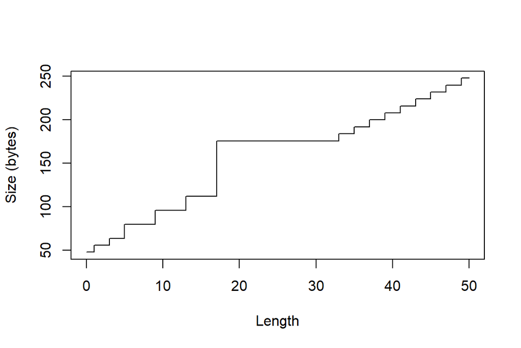

```r
sizes <- sapply(0:50, function(n) object_size(seq_len(n)))
plot(0:50, sizes, xlab = "Length", ylab = "Size (bytes)",
     type = "s")
```

## Profiling Memory: Pryr

another feature in R is that it tries to save memory by using pointers to existing memory allocations:

```r
x <- 1:1e6
object_size(x)
```

```
## 4 MB
```

```r
y <- list(x, x, x)
object_size(y)
```

```
## 4 MB
```

## Profiling Memory: Pryr

```r
object_size(x, y)
```

```
## 4 MB
```

after modifying one element of the list we get a different value:

```r
y[[1]] <- as.integer(x+1-1)
object_size(y)
```

```
## 8 MB
```

## Profiling Memory: Lineprof

Lineprof package can be installed with:

```r
devtools::install_github("hadley/lineprof")
```

## Profiling Memory: Lineprof

```r
library(lineprof)
siml <- function(l) {
  c <- rep(0,l);
  hits <- 0
  listp <- as.list(seq(10000000))
  pow2 <- function(x) { x2 <- sqrt( x[1]*x[1]+x[2]*x[2] ); return(x2) }
  for(i in 1:l){
    x = runif(2,-1,1)
    if( pow2(x) <=1 ){ hits <- hits + 1 }
    dens <- hits/i; pi_partial = dens*4; c[i] = pi_partial
  }

  return(c)
}
```

## Profiling Memory: Lineprof

```r
prof <- lineprof(siml(1000000))
prof

Output:
     time   alloc release dups                                   ref
1   0.009   5.624   0.000 1808 c("compiler:::tryCmpfun", "tryCatch")
2   0.002   0.100   0.000  235                          character(0)
3   0.520 556.091   5.220    2       c("as.list", "as.list.default")
4   0.001   5.332   0.000    0                               "runif"
5   0.001   5.253   0.000    0                          character(0)
6   0.001   5.197   0.000    0                                    #6
7   0.009  17.406  16.858    0                               "runif"
8   0.001   8.230   0.000    0                          character(0)
9   0.019  24.799  48.774    0                               "runif"
10  0.001  11.420   0.000    0                          character(0)
11  0.002   7.451   0.000    0                               "runif"
...
```

## Dealing with big arrays

For big data file we can use **memory-mapped** files with the **bigmemory** package. In case the **bigmemory** package is not installed execute the command:

```r
install.packages("bigmemory")
```

```r
library(bigmemory)
bm <- big.matrix(1e8, 3, backingfile = "bm", backingpath = getwd())
bm
```

the large array can be retrieved for subsequent use as follows:

```r
my.bm <- attach.big.matrix(file.path(getwd(), "bm.desc"))
```

## Dealing with big arrays

now, work with chunks of \(10^7\) rows,

```r
chunksize <- 1e7
start <- 1
while (start <= nrow(bm)) {
  end <- min(start + chunksize -1, nrow(bm))
  chunksize <- end - start + 1
  bm[start:end, 1] <- rpois(chunksize, 1e3)
  bm[start:end, 2] <- sample(0:1, chunksize, TRUE, c(0.7,0.3))
  bm[start:end, 3] <- runif(chunksize, 0, 1e5)
  start <- start + chunksize
}
```

## References

- https://swcarpentry.github.io/r-novice-inflammation/
- https://www.tutorialspoint.com/r/index.htm
- R High Performance Programming. Aloysius, Lim; William, Tjhi. Packt Publishing, 2015.
- http://adv-r.had.co.nz/memory.html
- https://blogs.oracle.com/r/managing-memory-limits-and-configuring-exadata-for-embedded-r-execution